# Capsule 1 - Reconnaître une relation non linéaire

MQT-2101 - Analyse et modélisation des données

## Pourquoi ça compte

La hausse reste-t-elle la même à tous les niveaux d’achalandage?

Une direction veut estimer ses ventes. Une droite suppose une variation moyenne constante; les données peuvent suggérer un ralentissement.

## Objectifs de la capsule

- Définir la question et les unités.
- Repérer une courbure possible.
- Préparer une comparaison reproductible.

## Le cas et l’unité d’observation

72

observations mois-succursale

6

succursales fictives

2025

douze mois de suivi

Une ligne décrit un mois dans une succursale. Les données sont simulées; les ventes sont en dollars canadiens.

## Préparer le projet

- Projet RStudio : `comparaison-achalandage`.
- CSV dans le dossier `data`.
- Rapport : `comparaison_achalandage.qmd`.

Le code complet et les clics sont dans les démonstrations R.

## Garder les derniers mois pour comparer

54

janvier à septembre : apprentissage

18

octobre à décembre : validation

3

formes candidates fixées avant la comparaison

Explorer et ajuster sur l’apprentissage. Comparer ensuite sur la validation.

## Lire le nuage avant de choisir

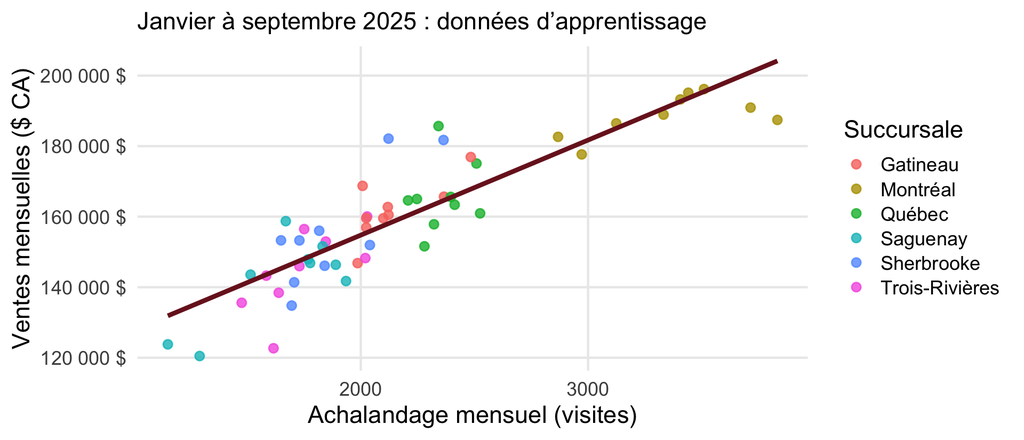

## Ce qu’une droite impose

$$\widehat{y}=b_0+b_1x$$

- Une même hausse de x donne une même hausse prédite.
- Une courbe permet une variation qui dépend du point de départ.
- La dispersion autour de la tendance demeure.

## Une question statistique précise

Comment les ventes mensuelles moyennes varient-elles avec l’achalandage, dans les succursales observées?

Cela ne mesure pas l’effet causal d’attirer des visites supplémentaires.

## À retenir

Question

variables et unités explicites

Forme

lire avant d’ajuster

Limite

association, sans causalité établie

## Production autonome 4.1

Produisez le nuage achalandage-ventes sur janvier à septembre. Décrivez la direction, une courbure possible et la dispersion. Nommez les unités et une limite.

### Auto-vérification

- J’ai utilisé les 54 observations d’apprentissage.
- Mes axes indiquent les visites et les dollars.
- Je distingue forme observée et explication causale.